# Analysis of ATAC-seq data in R and Bioconductor

# Aligning Sequence Reads to the Genome.

We can now use the **qAlign()** function to align our data.

The **qAlign()** function requires the path to our sample table file and the path of a FASTA file to align sequence reads against.

```r
library(QuasR)
qAlign("sampleTable.txt","BSgenome.Hsapiens.UCSC.hg19.mainChrs.fa")
```

### Creating Rsubread index

Index building is part of the **QuasR** alignment process but for Rsubread we must build our index prior to Rsubread’s alignment steps.

Rsubread’s [**buildindex()** function simply takes the parameters of our desired index name and the FASTA file to build index from.](https://rockefelleruniversity.github.io/Bioconductor_Introduction/r_course/presentations/slides/AlignmentInBioconductor.html#34).

Here i additional specify the parameter **indexSplit** as TRUE in conjunction with **memory** parameter set to 1000 (1000MB) to control memory usage in Rsubread alignment step.

```r
library(Rsubread)
buildindex("BSgenome.Hsapiens.UCSC.hg19.mainChrs",
           "BSgenome.Hsapiens.UCSC.hg19.mainChrs.fa",
           indexSplit = TRUE,
           memory = 1000)
```

### Sorting and Indexing

Following alignment [we would want to sort and index our BAM file for use with external tool.](https://rockefelleruniversity.github.io/Bioconductor_Introduction/r_course/presentations/slides/AlignedDataInBioconductor.html#10)

First we sort our aligned data by sequence order (not Read Name here).

We then index our file allowing for rapid access of particular genomic locations by other programs (e.g IGV, Samtools) and by R/Bioconductor packaes we will use.

```r
library(Rsamtools)
sortedBAM <- file.path(dirname(outBAM),
                       paste0("Sorted_",basename(outBAM))
                       )

sortBam(outBAM,gsub("\\.bam","",basename(sortedBAM)))
indexBam(sortedBAM)
```

```r
sortedBAM <- "~/Downloads/demo/ATAC_Workshop/ATAC_Data/ATAC_BAM/Sorted_ATAC_50K_2.bam"
```

### Distribution of mapped reads

We can now use the mapped reads data frame to make a barplot of reads across chromosomes.

In this example, we see a case where the mapping rate to mitochondrial genome is high.

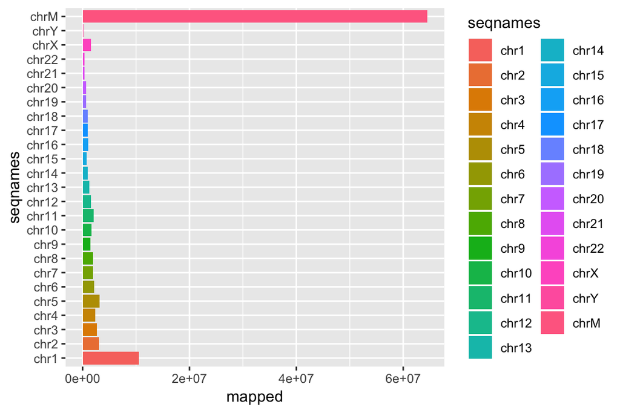

```r
library(ggplot2)

ggplot(mappedReads,aes(seqnames,mapped,fill=seqnames))+
  geom_bar(stat="identity")+coord_flip()
```

## Greenleaf dataset post-alignment processing.

We can now use these flags with the **ScanBamParam()** function to read in only properly paired reads.

We additionally specify information to be read into R using the **what** parameter. Importantly we specify the insert size information - **isize**. To reduce memory footprint we read only information from chromosome 20 by specifying a GRanges object to **which** parameter.

```r
myParam=ScanBamParam(flag=flags,
                   what=c("qname","mapq","isize"),
                   which=GRanges("chr20", IRanges(1,63025520)))
myParam
```

```
## class: ScanBamParam
## bamFlag (NA unless specified): isProperPair=TRUE
## bamSimpleCigar: FALSE
## bamReverseComplement: FALSE
## bamTag:
## bamTagFilter:
## bamWhich: 1 ranges
## bamWhat: qname, mapq, isize
## bamMapqFilter: NA
```

## Greenleaf dataset post-alignment processing.

The **GAlignmentPairs** object contains information on our paired reads.

It stores information on each read in a pair in parallel **GAlignments** objects.

```r
atacReads[1:2,]
```

```
## GAlignmentPairs object with 2 pairs, strandMode=1, and 0 metadata columns:
##       seqnames strand :         ranges --         ranges
##          <Rle>  <Rle> :      <IRanges> --      <IRanges>
##   [1]    chr20      + : [60000, 60029] -- [60361, 60410]
##   [2]    chr20      + : [60000, 60029] -- [60361, 60410]
##   -------
##   seqinfo: 25 sequences from an unspecified genome
```

### Retrieving insert sizes

Now we have read in the paired aligned data into R, we can retreive the insert sizes from the elementMetadata attached to **GAlignments** objects of each read pair.

Since properly paired reads will have the same insert size length we extract insert sizes from read1.

```r
atacReads_read1 <- first(atacReads)
insertSizes <- abs(elementMetadata(atacReads_read1)$isize)
head(insertSizes)
```

[output not shown]

### Plotting insert sizes

Now we can use the newly acquired insert lengths for chromosome 20 to plot the distribution of all fragment lengths.

```r
toPlot <- data.frame(InsertSize=as.numeric(names(fragLenSizes)),
                            Count=as.numeric(fragLenSizes))
fragLenPlot <- ggplot(toPlot,aes(x=InsertSize,y=Count))+geom_line()
```

### Plotting insert sizes

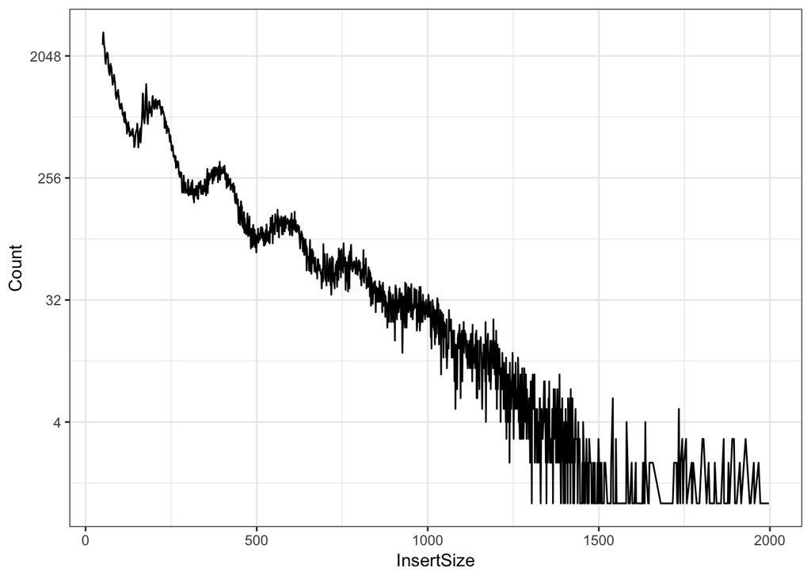

```r
fragLenPlot + scale_y_continuous(trans='log2')+theme_bw()
```

### Subsetting ATAC-seq reads files by insert sizes.

We may wish to divide our aligned reads into reads representing nucleosome free and nucleosome occupied.

Here we create BAM files for the reads representing nucleosome free, mono and di nucleosome by using insert sizes to filter read.

```r
atacReads_Open <- atacReads[insertSizes < 100,]
atacReads_MonoNuc <- atacReads[insertSizes > 180 &
                                 insertSizes < 240,]
atacReads_diNuc <- atacReads[insertSizes > 315 &
                               insertSizes < 437,]
```

### Creating an open region bigWig.

We can make it significantly quicker to review the pile-up of ATAC-seq signal in a genome browser by creating a bigWig file.

Here we use the **granges()** function to recreate full fragments from the paired single-end reads.

```r
atacReads_Open[1,]
```

```
## GAlignmentPairs object with 1 pair, strandMode=1, and 0 metadata columns:
##       seqnames strand :         ranges --         ranges
##          <Rle>  <Rle> :      <IRanges> --      <IRanges>
##   [1]    chr20      + : [60436, 60485] -- [60446, 60495]
##   -------
##   seqinfo: 25 sequences from an unspecified genome
```

```r
atacFragments_Open <- granges(atacReads_Open)
atacFragments_Open[1,]
```

```
## GRanges object with 1 range and 0 metadata columns:
##       seqnames         ranges strand
##          <Rle>      <IRanges>  <Rle>
##   [1]    chr20 [60436, 60495]      +
##   -------
##   seqinfo: 25 sequences from an unspecified genome
```

# Time for an exercise.

Link_to_exercises

Link_to_answers